# Homework 6

We can first load the data and get an overview of how it looks:

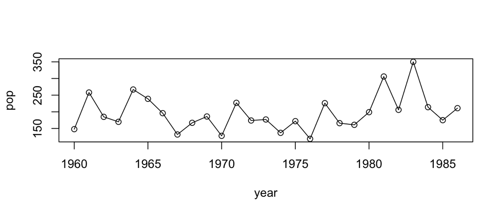

#### Question 6.1. Reformulating the Ricker model

```r
parus <- pomp(dat,times="year",t0=1959)

# Add the process model simulator
latent <- Csnippet("N = r*N*exp(-N/k);")
parus <- pomp(parus,rprocess=discrete_time(step.fun=latent,delta.t=1),statenames="N",paramnames=c("r","k"))
```

Since the arguments for negative binomial in `Csnippet` are `size` and `prob`, we can find the relationship between `size` and `mu` to determine the formulas of arguments.

According to the R document of `rnbinom`, the relationship between `size`, `mu` and `prob` is `prob = size/(size+mu)`. Therefore, denote $s$ for `size`, we have
$$\left\{\begin{array}{l}
p = \frac{s}{s+\mu}, \\
\mu = \phi P_n
\end{array}\right.
\quad \Rightarrow \quad s = \frac{p}{1-p}\mu = \frac{\phi p}{1-p}N$$
Denote this $\phi' = \phi p/(1-p)$, the size is proportional to $P_n$, and we can use `phi` to represent this coefficient,

```r
# Add the measurement model
rmeas <- Csnippet("pop = rnbinom(phi*N,p);")
dmeas <- Csnippet("lik = dnbinom(pop,phi*N,p,give_log);")
parus <- pomp(parus,rmeasure=rmeas,dmeasure=dmeas,statenames=c("N"), paramnames=c("phi","p"))
```

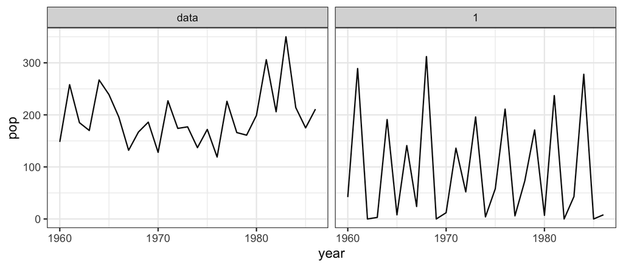

```r
# simulation
coef(parus) <- c(N.0=0.1,r=30,phi=20,k=2,p=0.6)
sims <- simulate(parus,nsim=1,format="data.frame",include.data=TRUE)
ggplot(data=sims,mapping=aes(x=year,y=pop))+geom_line()+facet_wrap(~.id)
```

#### Question 6.2. Coding a new POMP model

```r
parus2 <- pomp(dat,times="year",t0=1959)

# Add the process model simulator
stochStep <- Csnippet("
  e = rlnorm(10.5*sigma*sigma,sigma);
  N = a*N*e/(1+b*N);
")
parus2 <- pomp(parus2,rprocess=discrete_time(step.fun=stochStep,delta.t=1), paramnames=c("a","b","sigma"),statenames=c("N","e"))
```

```r
# Add the measurement model
rmeas2 <- Csnippet("pop = rnbinom(phi*N,p);")
dmeas2 <- Csnippet("lik = dnbinom(pop,phi*N,p,give_log);")
parus2 <- pomp(parus2,rmeasure=rmeas2,dmeasure=dmeas2,statenames=c("N"), paramnames=c("phi","p"))
```

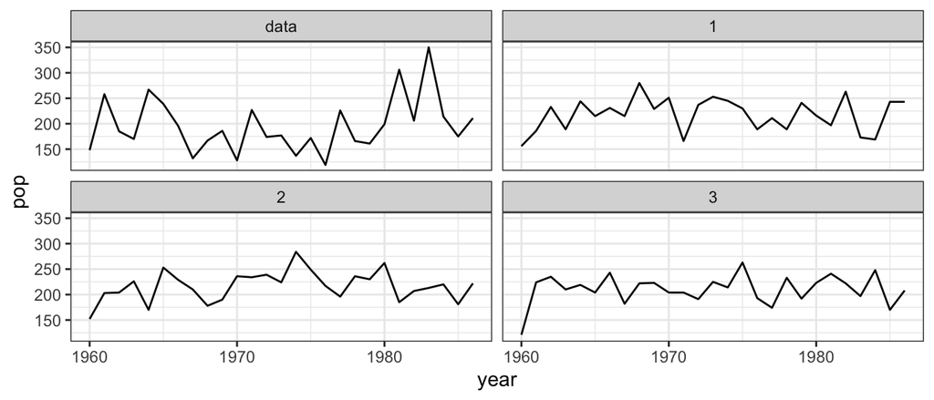

```r
# simulation
coef(parus2) <- c(N.0=1,e.0=0,a=30,b=2,sigma=0.1,phi=20,k=2,p=0.6)
sims <- simulate(parus2,nsim=3,format="data.frame",include.data=TRUE)
ggplot(data=sims,mapping=aes(x=year,y=pop))+geom_line()+facet_wrap(~.id)
```

#### Question 6.3

1. Reference: https://cran.r-project.org/doc/manuals/r-release/R-exts.html#Distribution-functions
2. It took me about 2 hours to finish this homework. I first spent some time understanding the relationship between process model and measurement model. Then I tried to understand the arguments of `rnbinom` in `Csnippet`, because it always generates compilation error. Then I found the reference in (a) really helpful, and set argumments accordingly. After I finished question 6.1, it took me abuot 5 minutes to finish question 6.2. In addition I spent some time varying the parameters in simulation to explore the impact they have on simulation.